# ARE 213 Problem Set 1b

Nick Depsky, Will Gorman, Peter Worley

October 12, 2018

Import Data

```r
#setwd("~/Dropbox/Berkeley_tings/Fall 2018/ARE213/Problem Sets/SharedFiles/are213/PS1b")
dat <- read.dta("ps1.dta")
#fix missing data
dat_drop <- dat %>% filter(herpes != 8 & tobacco != 9 & cigar != 99 & cigar6 != 6 &
                  alcohol != 9 & drink != 99 & drink5 != 5 & wgain != 99)
dat_drop$tobacco[dat_drop$tobacco == 2] <- 0
setwd("/Users/nicholasdepsky/Dropbox/Berkeley_tings/Fall 2018/ARE213/Problem Sets/SharedFiles/are213/PS1/")
```

[output not shown]

```r
load("white_df_ps1.Rdata")
load("vartab.Rdata")
dat.all <- cbind(dat_drop$dbrwt, white_df_ps1) %>% as.data.frame() %>% set_colnames(c("dbrwt",names(white_df_ps1)))
```

```r
dat.mod <- dat_drop %>% select(dbrwt,stresfip,dmage,ormoth,mrace3,dmeduc,dmar,adequacy,
               dtotord,monpre,nprevist,disllb,birmon,dgestat,csex,dplural,
               anemia,diabetes,herpes,chyper,pre4000,
               preterm,tobacco,cigar,alcohol,drink,wgain)
#dat.mod <- dat_drop %>% select(dbrwt,dmage,dmeduc,dmar,adequacy,
               #dtotord,monpre,nprevist,disllb,birmon,dgestat,csex,dplural,
               #anemia,diabetes,herpes,chyper,pre4000,
               #preterm,tobacco,cigar,alcohol,drink,wgain)
lm.mod <- lm(dbrwt ~., data = dat.mod)
summary(lm.mod)
```

```
Call:
lm(formula = dbrwt ~ ., data = dat.mod)

Residuals:
     Min       1Q   Median       3Q      Max
-2942.57  -289.14    -5.04   284.58  2741.78

Coefficients:
              Estimate Std. Error t value Pr(>|t|)
(Intercept)  6.420e+01  7.987e+01   0.804  0.42149
stresfip     9.177e-01  6.158e-01   1.490  0.13619
dmage        1.750e+00  3.134e-01   5.583 2.36e-08 ***
ormoth      -2.732e+01  2.606e+00 -10.485  < 2e-16 ***
mrace3      -6.862e+01  2.281e+00 -30.075  < 2e-16 ***
dmeduc       4.960e+00  7.031e-01   7.055 1.74e-12 ***
dmar        -4.816e+01  3.942e+00 -12.216  < 2e-16 ***
adequacy     1.011e+01  4.007e+00   2.524  0.01160 *
dtotord      8.995e+00  1.183e+00   7.606 2.84e-14 ***
monpre       1.564e+00  1.373e+00   1.139  0.25453
nprevist     8.887e+00  5.195e-01  17.107  < 2e-16 ***
disllb      -1.951e-01  4.711e-03 -41.414  < 2e-16 ***
birmon      -3.955e-01  3.928e-01  -1.007  0.31391
dgestat      1.066e+02  5.862e-01 181.920  < 2e-16 ***
csex        -1.329e+02  2.668e+00 -49.825  < 2e-16 ***
dplural     -6.466e+02  7.965e+00 -81.177  < 2e-16 ***
anemia      -2.601e+01  1.344e+01  -1.935  0.05296 .
diabetes    -1.586e+02  8.325e+00 -19.047  < 2e-16 ***
herpes      -1.500e+01  1.707e+01  -0.879  0.37945
chyper       1.281e+02  1.531e+01   8.364  < 2e-16 ***
pre4000     -3.768e+02  1.125e+01 -33.499  < 2e-16 ***
preterm      2.528e+02  1.141e+01  22.166  < 2e-16 ***
tobacco     -1.579e+02  6.569e+00 -24.033  < 2e-16 ***
cigar       -3.805e+00  4.498e-01  -8.459  < 2e-16 ***
alcohol      4.683e+01  1.585e+01   2.955  0.00313 **
drink       -1.614e-01  2.494e+00  -0.065  0.94839
wgain        8.257e+00  1.157e-01  71.353  < 2e-16 ***
---
Signif. codes:  0 ‘***’ 0.001 ‘**’ 0.01 ‘*’ 0.05 ‘.’ 0.1 ‘ ’ 1

Residual standard error: 450.9 on 114583 degrees of freedom
Multiple R-squared:  0.4065,    Adjusted R-squared:  0.4063
F-statistic:  3018 on 26 and 114583 DF,  p-value: < 2.2e-16
```

# 1a - Misspecification bias

There are a number of possible sources for misspecification bias in our linear model estimates from PS1a. For one, the control variables, including the treatment variable, are all assumed to have linear effects on the outcome variable, which may or may not be the correct functional form of the model, as some effects may in fact be non-linear, or there may exist important interaction effects between controls that were not considered. Secondly, it is possible that there still remain unobserved variables correlated with either our outcome or control variables that were omitted from the model, causing omitted variables bias. Perhaps most importantly, however, is the likelihood that there exists some issue of endogeneity between the outcome variable and some of the control. For example, smoking while pregnant may contribute to hypertension, cardiac issues, or other factors that were considered in our initial model as control variables independent of the outcome variable.

# 1b - Series Estimator, One Squared Term, One Interaction Term

```r
dat.ser <- dat.mod
dat.ser$drinksq <- dat.ser$drink^2
dat.ser$cig_drink <- dat.ser$cigar*dat.ser$drink
poly.mod <- lm(dbrwt ~., data = dat.ser)
summary(poly.mod)
```

```
Call:
lm(formula = dbrwt ~ ., data = dat.ser)

Residuals:
     Min       1Q   Median       3Q      Max
-2942.37  -289.21    -4.99   284.62  2741.71

Coefficients:
              Estimate Std. Error t value Pr(>|t|)
(Intercept)  1.530e+02  8.265e+01   1.851  0.06419 .
stresfip     9.223e-01  6.158e-01   1.498  0.13422
dmage        1.755e+00  3.134e-01   5.601 2.14e-08 ***
ormoth      -2.733e+01  2.606e+00 -10.491  < 2e-16 ***
mrace3      -6.853e+01  2.281e+00 -30.039  < 2e-16 ***
dmeduc       4.937e+00  7.031e-01   7.022 2.20e-12 ***
dmar        -4.801e+01  3.942e+00 -12.180  < 2e-16 ***
adequacy     1.024e+01  4.006e+00   2.555  0.01062 *
dtotord      9.005e+00  1.182e+00   7.616 2.65e-14 ***
monpre       1.555e+00  1.373e+00   1.133  0.25741
nprevist     8.882e+00  5.195e-01  17.099  < 2e-16 ***
disllb      -1.951e-01  4.711e-03 -41.409  < 2e-16 ***
birmon      -3.931e-01  3.927e-01  -1.001  0.31682
dgestat      1.066e+02  5.861e-01 181.939  < 2e-16 ***
csex        -1.329e+02  2.668e+00 -49.830  < 2e-16 ***
dplural     -6.463e+02  7.964e+00 -81.155  < 2e-16 ***
anemia      -2.605e+01  1.344e+01  -1.938  0.05261 .
diabetes    -1.586e+02  8.324e+00 -19.051  < 2e-16 ***
herpes      -1.487e+01  1.707e+01  -0.871  0.38356
chyper       1.282e+02  1.531e+01   8.371  < 2e-16 ***
pre4000     -3.767e+02  1.125e+01 -33.491  < 2e-16 ***
preterm      2.527e+02  1.141e+01  22.153  < 2e-16 ***
tobacco     -1.579e+02  6.579e+00 -24.006  < 2e-16 ***
cigar       -3.788e+00  4.518e-01  -8.385  < 2e-16 ***
alcohol      1.933e+00  1.916e+01   0.101  0.91965
drink       -1.918e+01  5.944e+00  -3.228  0.00125 **
wgain        8.256e+00  1.157e-01  71.347  < 2e-16 ***
drinksq      3.241e-01  7.389e-02   4.387 1.15e-05 ***
cig_drink    8.309e-02  2.229e-01   0.373  0.70927
---
Signif. codes:  0 ‘***’ 0.001 ‘**’ 0.01 ‘*’ 0.05 ‘.’ 0.1 ‘ ’ 1

Residual standard error: 450.8 on 114581 degrees of freedom
Multiple R-squared:  0.4066,    Adjusted R-squared:  0.4064
F-statistic:  2804 on 28 and 114581 DF,  p-value: < 2.2e-16
```

# 1b - Series Estimator, Higher order Polynomial specifications

Performance was assessed using up to order 3, 4, 5 polynomial orders, and all were similar, with small R2 gains from 3 to 4, but not from 4 to 5.

```r
poly.mod <- lm(dbrwt ~ poly(stresfip,4,raw=T)+poly(dmage,4,raw=T)+poly(ormoth,4,raw=T)+poly(mrace3,4,raw=T)+poly(dmeduc,4,raw=T)+poly(dmar,4,raw=T)+poly(adequacy,4,raw=T)+poly(dtotord,4,raw=T)+poly(monpre,4,raw=T)+poly(nprevist,4,raw=T)+poly(disllb,4,raw=T)+poly(birmon,4,raw=T)+poly(dgestat,4,raw=T)+poly(csex,4,raw=T)+poly(dplural,4,raw=T)+poly(anemia,4,raw=T)+poly(diabetes,4,raw=T)+poly(herpes,4,raw=T)+poly(chyper,4,raw=T)+poly(pre4000,4,raw=T)+poly(preterm,4,raw=T)+poly(tobacco,4,raw=T)+poly(cigar,4,raw=T)+poly(alcohol,4,raw=T)+poly(drink,4,raw=T)+poly(wgain,4,raw=T), data = dat_drop)
summary(poly.mod)
```

```
Call:
lm(formula = dbrwt ~ poly(stresfip, 4, raw = T) + poly(dmage,
    4, raw = T) + poly(ormoth, 4, raw = T) + poly(mrace3, 4,
    raw = T) + poly(dmeduc, 4, raw = T) + poly(dmar, 4, raw = T) +
    poly(adequacy, 4, raw = T) + poly(dtotord, 4, raw = T) +
    poly(monpre, 4, raw = T) + poly(nprevist, 4, raw = T) + poly(disllb,
    4, raw = T) + poly(birmon, 4, raw = T) + poly(dgestat, 4,
    raw = T) + poly(csex, 4, raw = T) + poly(dplural, 4, raw = T) +
    poly(anemia, 4, raw = T) + poly(diabetes, 4, raw = T) + poly(herpes,
    4, raw = T) + poly(chyper, 4, raw = T) + poly(pre4000, 4,
    raw = T) + poly(preterm, 4, raw = T) + poly(tobacco, 4, raw = T) +
    poly(cigar, 4, raw = T) + poly(alcohol, 4, raw = T) + poly(drink,
    4, raw = T) + poly(wgain, 4, raw = T), data = dat_drop)

Residuals:
     Min       1Q   Median       3Q      Max
-2888.50  -286.96   -14.38   270.36  2983.43

Coefficients: (35 not defined because of singularities)
                              Estimate Std. Error t value Pr(>|t|)
(Intercept)                 -1.796e+02  1.815e+03  -0.099 0.921202
poly(stresfip, 4, raw = T)1  2.129e+01  1.734e+01   1.227 0.219671
poly(stresfip, 4, raw = T)2 -1.537e+00  9.957e-01  -1.544 0.122612
poly(stresfip, 4, raw = T)3  4.165e-02  2.296e-02   1.814 0.069645 .
poly(stresfip, 4, raw = T)4 -3.757e-04  1.864e-04  -2.016 0.043822 *
poly(dmage, 4, raw = T)1    -2.595e+01  4.604e+01  -0.564 0.572910
poly(dmage, 4, raw = T)2     1.708e+00  2.520e+00   0.677 0.498107
poly(dmage, 4, raw = T)3    -4.113e-02  5.987e-02  -0.687 0.492067
poly(dmage, 4, raw = T)4     3.327e-04  5.213e-04   0.638 0.523378
poly(ormoth, 4, raw = T)1    6.212e+01  8.031e+01   0.773 0.439252
poly(ormoth, 4, raw = T)2   -1.428e+02  7.898e+01  -1.809 0.070527 .
poly(ormoth, 4, raw = T)3    5.373e+01  2.403e+01   2.236 0.025330 *
poly(ormoth, 4, raw = T)4   -5.648e+00  2.310e+00  -2.445 0.014494 *
poly(mrace3, 4, raw = T)1   -5.064e+02  3.793e+01 -13.352  < 2e-16 ***
poly(mrace3, 4, raw = T)2    1.110e+02  9.580e+00  11.586  < 2e-16 ***
poly(mrace3, 4, raw = T)3           NA         NA      NA       NA
poly(mrace3, 4, raw = T)4           NA         NA      NA       NA
poly(dmeduc, 4, raw = T)1    7.656e+01  2.794e+01   2.740 0.006147 **
poly(dmeduc, 4, raw = T)2   -1.847e+01  4.673e+00  -3.953 7.74e-05 ***
poly(dmeduc, 4, raw = T)3    1.462e+00  3.227e-01   4.530 5.91e-06 ***
```

[output cut: 76 more lines]

```
poly(alcohol, 4, raw = T)4          NA         NA      NA       NA
poly(drink, 4, raw = T)1    -4.602e+01  1.264e+01  -3.642 0.000271 ***
poly(drink, 4, raw = T)2     3.098e+00  1.155e+00   2.682 0.007314 **
poly(drink, 4, raw = T)3    -6.451e-02  2.950e-02  -2.187 0.028754 *
poly(drink, 4, raw = T)4     4.118e-04  2.063e-04   1.996 0.045913 *
poly(wgain, 4, raw = T)1    -9.557e+00  1.382e+00  -6.918 4.61e-12 ***
poly(wgain, 4, raw = T)2     6.532e-01  6.375e-02  10.246  < 2e-16 ***
poly(wgain, 4, raw = T)3    -8.873e-03  1.154e-03  -7.687 1.52e-14 ***
poly(wgain, 4, raw = T)4     3.703e-05  6.958e-06   5.323 1.03e-07 ***
---
Signif. codes:  0 ‘***’ 0.001 ‘**’ 0.01 ‘*’ 0.05 ‘.’ 0.1 ‘ ’ 1

Residual standard error: 437.3 on 114540 degrees of freedom
Multiple R-squared:  0.4418,    Adjusted R-squared:  0.4415
F-statistic:  1314 on 69 and 114540 DF,  p-value: < 2.2e-16
```

# 1b - Series Estimator, Squared Terms and Interaction Terms

```r
all.mod <- lm(dbrwt ~., data = dat.all)
summary(all.mod)
```

```
Call:
lm(formula = dbrwt ~ ., data = dat.all)

Residuals:
    Min      1Q  Median      3Q     Max
-3725.3  -275.6     3.6   283.2  2163.8

Coefficients: (12 not defined because of singularities)
                    Estimate Std. Error t value Pr(>|t|)
(Intercept)       -7.404e+03  3.929e+03  -1.885 0.059476 .
stresfip           6.740e+01  4.870e+01   1.384 0.166390
dmage             -1.622e+01  1.867e+01  -0.869 0.384955
ormoth             2.719e+02  1.767e+02   1.538 0.123938
mrace3            -2.794e+02  1.346e+02  -2.076 0.037865 *
dmeduc            -6.434e+01  4.452e+01  -1.445 0.148349
dmar               4.460e+02  2.376e+02   1.877 0.060484 .
adequacy           1.558e+02  2.321e+02   0.672 0.501848
dtotord           -1.439e+02  6.301e+01  -2.283 0.022424 *
monpre             2.115e+02  7.620e+01   2.775 0.005521 **
nprevist           2.186e+01  2.920e+01   0.749 0.454031
disllb            -3.207e+00  1.157e+00  -2.773 0.005560 **
birmon            -1.543e+01  2.441e+01  -0.632 0.527359
dgestat            6.254e+02  3.262e+01  19.175  < 2e-16 ***
csex               2.314e+02  1.625e+02   1.424 0.154592
dplural            1.297e+03  5.314e+02   2.440 0.014688 *
anemia            -1.490e+02  6.493e+02  -0.229 0.818543
diabetes          -4.905e+02  4.414e+02  -1.111 0.266509
herpes             1.118e+03  9.327e+02   1.199 0.230530
chyper            -1.552e+03  1.251e+03  -1.241 0.214502
pre4000           -7.087e+02  6.880e+02  -1.030 0.302993
preterm            3.684e+02  5.863e+02   0.628 0.529713
tobacco           -8.477e+02  3.857e+02  -2.198 0.027975 *
cigar             -5.079e+01  2.600e+01  -1.953 0.050773 .
alcohol           -2.333e+03  1.549e+03  -1.506 0.132044
drink             -4.394e+02  8.422e+02  -0.522 0.601826
wgain              5.033e+00  6.816e+00   0.738 0.460254
stresfip_2        -3.064e-02  5.012e-02  -0.611 0.541069
dmage_2           -3.926e-01  5.261e-02  -7.462 8.55e-14 ***
ormoth_2           1.168e+01  1.875e+00   6.230 4.70e-10 ***
mrace3_2           1.153e+02  1.002e+01  11.509  < 2e-16 ***
```

[output cut: 161 more lines]

```
adequacy_birmon    1.872e+00  1.150e+00   1.628 0.103630
adequacy_dgestat  -6.750e-02  1.423e+00  -0.047 0.962162
adequacy_csex     -9.206e+00  7.811e+00  -1.179 0.238537
adequacy_dplural  -2.711e+01  2.381e+01  -1.139 0.254901
adequacy_anemia   -6.830e+01  3.446e+01  -1.982 0.047464 *
adequacy_diabetes  5.478e+01  2.483e+01   2.206 0.027361 *
adequacy_herpes   -9.479e+00  5.484e+01  -0.173 0.862775
adequacy_chyper    3.214e+01  4.485e+01   0.717 0.473621
 [ reached getOption("max.print") -- omitted 179 rows ]
---
Signif. codes:  0 ‘***’ 0.001 ‘**’ 0.01 ‘*’ 0.05 ‘.’ 0.1 ‘ ’ 1

Residual standard error: 437 on 114243 degrees of freedom
Multiple R-squared:  0.4441,    Adjusted R-squared:  0.4423
F-statistic: 249.4 on 366 and 114243 DF,  p-value: < 2.2e-16
```

Equal quantile knots were assessed with 3, 4, and 5 knots. All produced almost identical results, so 3 was used.

```r
# Find knots based on equal quantiles of data
nknots <- 3
knots <- attr(bs(dat_drop$dbrwt, df = nknots+3), "knots")
cspline.mod <- lm(dbrwt ~ bs(stresfip,knots = knots)+bs(dmage,knots = knots)+bs(ormoth,knots = knots)+bs(mrace3,knots = knots)+bs(dmeduc,knots = knots)+bs(dmar,knots = knots)+bs(adequacy,knots = knots)+bs(dtotord,knots = knots)+bs(monpre,knots = knots)+bs(nprevist,knots = knots)+bs(disllb,knots = knots)+bs(birmon,knots = knots)+bs(dgestat,knots = knots)+bs(csex,knots = knots)+bs(dplural,knots = knots)+bs(anemia,knots = knots)+bs(diabetes,knots = knots)+bs(herpes,knots = knots)+bs(chyper,knots = knots)+bs(pre4000,knots = knots)+bs(preterm,knots = knots)+bs(tobacco,knots = knots)+bs(cigar,knots = knots)+bs(alcohol,knots = knots)+bs(drink,knots = knots)+bs(wgain,knots = knots), data = dat_drop)
summary(cspline.mod)
```

```
Call:
lm(formula = dbrwt ~ bs(stresfip, knots = knots) + bs(dmage,
    knots = knots) + bs(ormoth, knots = knots) + bs(mrace3, knots = knots) +
    bs(dmeduc, knots = knots) + bs(dmar, knots = knots) + bs(adequacy,
    knots = knots) + bs(dtotord, knots = knots) + bs(monpre,
    knots = knots) + bs(nprevist, knots = knots) + bs(disllb,
    knots = knots) + bs(birmon, knots = knots) + bs(dgestat,
    knots = knots) + bs(csex, knots = knots) + bs(dplural, knots = knots) +
    bs(anemia, knots = knots) + bs(diabetes, knots = knots) +
    bs(herpes, knots = knots) + bs(chyper, knots = knots) + bs(pre4000,
    knots = knots) + bs(preterm, knots = knots) + bs(tobacco,
    knots = knots) + bs(cigar, knots = knots) + bs(alcohol, knots = knots) +
    bs(drink, knots = knots) + bs(wgain, knots = knots), data = dat_drop)

Residuals:
     Min       1Q   Median       3Q      Max
-2885.76  -287.16   -14.85   270.34  2989.09

Coefficients: (100 not defined because of singularities)
                              Estimate Std. Error t value Pr(>|t|)
(Intercept)                   1433.515    114.322  12.539  < 2e-16 ***
bs(stresfip, knots = knots)1  -168.880    158.538  -1.065 0.286772
bs(stresfip, knots = knots)2    41.321     63.050   0.655 0.512230
bs(stresfip, knots = knots)3   -69.843     97.371  -0.717 0.473203
bs(stresfip, knots = knots)4        NA         NA      NA       NA
bs(stresfip, knots = knots)5        NA         NA      NA       NA
bs(stresfip, knots = knots)6        NA         NA      NA       NA
bs(dmage, knots = knots)1       52.308     42.341   1.235 0.216688
bs(dmage, knots = knots)2      107.886     25.122   4.295 1.75e-05 ***
bs(dmage, knots = knots)3        8.624     47.409   0.182 0.855661
bs(dmage, knots = knots)4           NA         NA      NA       NA
bs(dmage, knots = knots)5           NA         NA      NA       NA
bs(dmage, knots = knots)6           NA         NA      NA       NA
bs(ormoth, knots = knots)1    -195.409     45.477  -4.297 1.73e-05 ***
bs(ormoth, knots = knots)2     -44.661     63.643  -0.702 0.482843
bs(ormoth, knots = knots)3     -65.251     18.624  -3.504 0.000459 ***
bs(ormoth, knots = knots)4          NA         NA      NA       NA
bs(ormoth, knots = knots)5          NA         NA      NA       NA
bs(ormoth, knots = knots)6          NA         NA      NA       NA
bs(mrace3, knots = knots)1    -429.623     25.036 -17.160  < 2e-16 ***
```

[output cut: 128 more lines]

```
bs(drink, knots = knots)4           NA         NA      NA       NA
bs(drink, knots = knots)5           NA         NA      NA       NA
bs(drink, knots = knots)6           NA         NA      NA       NA
bs(wgain, knots = knots)1     -115.327     25.471  -4.528 5.97e-06 ***
bs(wgain, knots = knots)2      846.225     26.244  32.245  < 2e-16 ***
bs(wgain, knots = knots)3      225.123     44.980   5.005 5.60e-07 ***
bs(wgain, knots = knots)4           NA         NA      NA       NA
bs(wgain, knots = knots)5           NA         NA      NA       NA
bs(wgain, knots = knots)6           NA         NA      NA       NA
---
Signif. codes:  0 ‘***’ 0.001 ‘**’ 0.01 ‘*’ 0.05 ‘.’ 0.1 ‘ ’ 1

Residual standard error: 437.7 on 114553 degrees of freedom
Multiple R-squared:  0.4409,    Adjusted R-squared:  0.4406
F-statistic:  1613 on 56 and 114553 DF,  p-value: < 2.2e-16
```

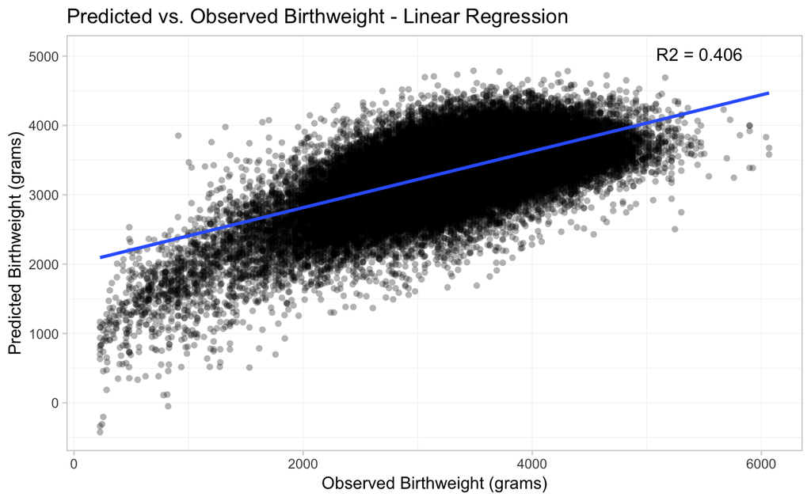

```r
ggscat(x = dat_drop$dbrwt, y = lm.mod$fitted.values, ylab = "Predicted Birthweight (grams)", xlab = "Observed Birthweight (grams)", title = "Predicted vs. Observed Birthweight - Linear Regression", fit = "linear", alpha = 0.3)
```

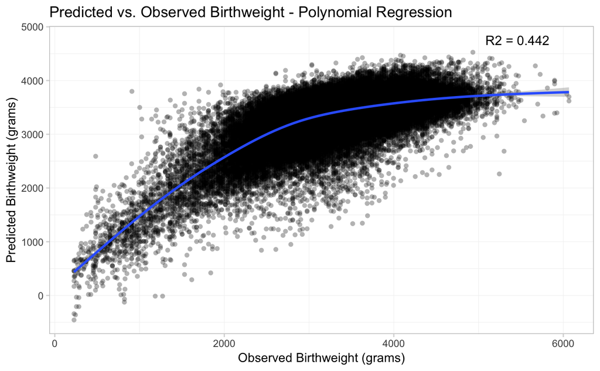

```r
ggscat(x = dat_drop$dbrwt, y = poly.mod$fitted.values, ylab = "Predicted Birthweight (grams)", xlab = "Observed Birthweight (grams)", title = "Predicted vs. Observed Birthweight - Polynomial Regression", fit = "smooth", alpha = 0.3)
```

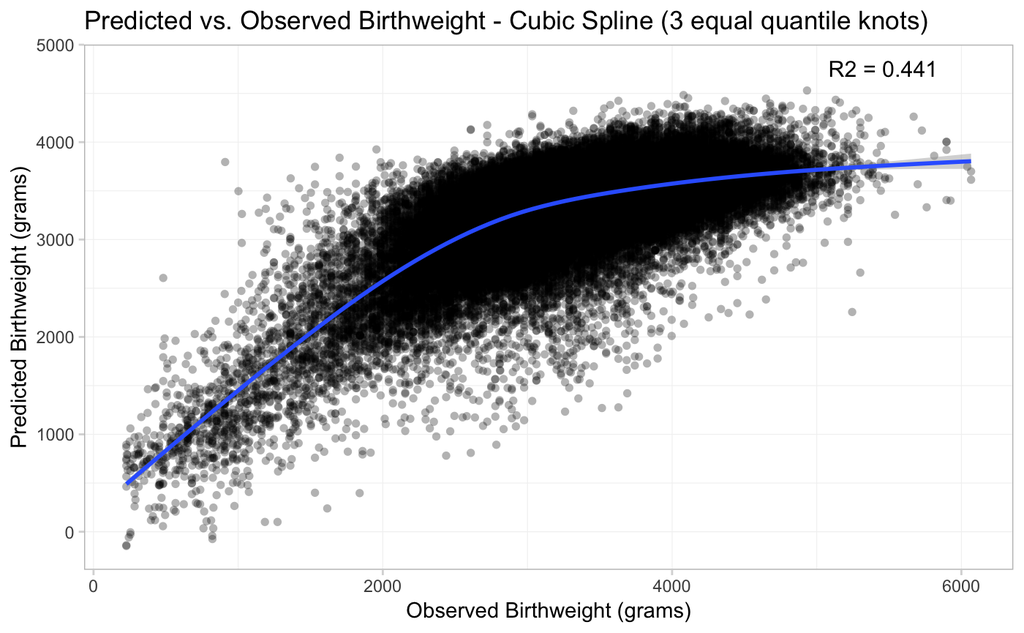

```r
ggscat(x = dat_drop$dbrwt, y =cspline.mod$fitted.values, ylab = "Predicted Birthweight (grams)", xlab = "Observed Birthweight (grams)", title =  paste0("Predicted vs. Observed Birthweight - Cubic Spline (",nknots," equal quantile knots)"), fit = "smooth", alpha = 0.3)
```

# 1c - Using LASSO

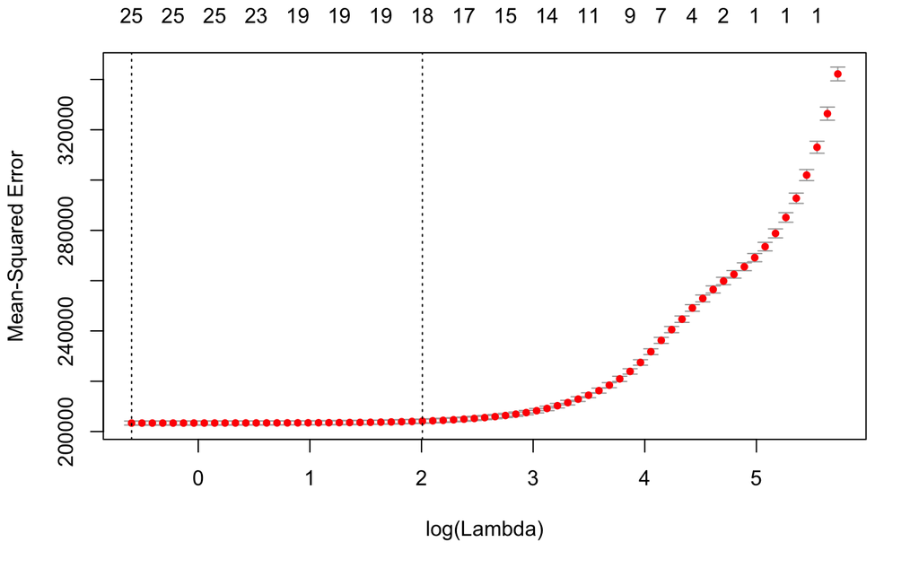

```r
n <- nrow(dat.mod)
k <- ncol(dat.mod)
y <- dat.mod$dbrwt
D <- dat.mod$tobacco
# X-matrix for the 1st step of Lasso with treatment as the outcome variable
xmat0 <- model.matrix(tobacco ~., data = dat.mod %>% select(-dbrwt))[,-1]
# X-matrix for the 2nd step of Lasso with original outcome as the outcome variable
xmat1 <- model.matrix(dbrwt ~., data = dat.mod)[,-1]
# Test which lambdas to use generally
cv.out <- cv.glmnet(xmat1, y, alpha = 1)
plot(cv.out)
```

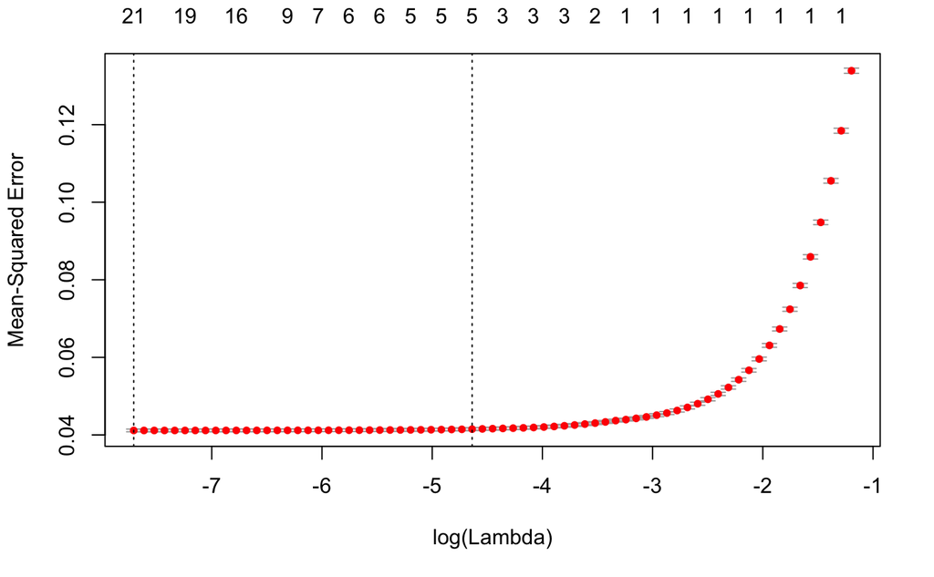

```r
# Treatment as Outcome
# Cross-Validation to Identify Lambdas to Use
cv.out <- cv.glmnet(xmat0, D, alpha = 1)
plot(cv.out)
```

```r
lasso.mod0 <- glmnet(xmat0, D, alpha = 1, lambda = cv.out$lambda.1se)
Dvars_save <- lasso.mod0$beta[abs(lasso.mod0$beta[,1])>0,1]
Dvars_save
```

```
        dmage        dmeduc          dmar         cigar       alcohol
-0.0001861988 -0.0044465717  0.0406821785  0.0542266793 -0.0218221446
```

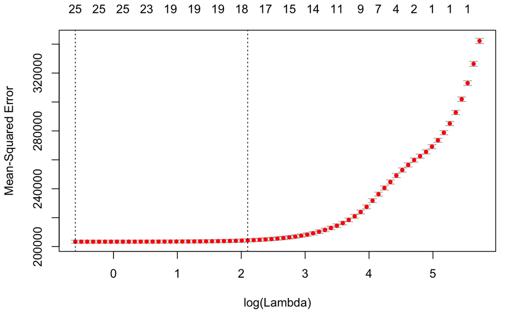

```r
# Treatment as Outcome
# Cross-Validation to Identify Lambdas to Use
cv.out <- cv.glmnet(xmat1, y, alpha = 1)
plot(cv.out)
```

```r
lasso.mod1 <- glmnet(xmat1, y, alpha = 1, lambda = cv.out$lambda.1se)
Ovars_save <- lasso.mod1$beta[abs(lasso.mod1$beta[,1])>0,1]
Ovars_save
```

```
       dmage       ormoth       mrace3       dmeduc         dmar      dtotord     nprevist       disllb      dgestat
   1.8789884  -11.3846399  -56.6878814    2.2385006  -49.0223989    3.2904105    6.0495317   -0.1779366  105.7146735
        csex      dplural     diabetes       chyper      pre4000      preterm      tobacco        cigar        wgain
-116.7619978 -591.4065047 -106.9476299   27.7206651 -328.3760521  182.2686546 -151.9900006   -2.6556231    7.5636369
```

```r
c(names(Dvars_save)[!which(names(Dvars_save) %in% names(Ovars_save))],names(Ovars_save))
```

```
 [1] "dmage"    "ormoth"   "mrace3"   "dmeduc"   "dmar"     "dtotord"  "nprevist" "disllb"   "dgestat"  "csex"     "dplural"
[12] "diabetes" "chyper"   "pre4000"  "preterm"  "tobacco"  "cigar"    "wgain"
```

# 2 - Propensity score description

# 2a - Create propensity score

Predetermined variables used for propensity score calculation using logit.

```r
pd.vars <- c("tobacco","dmage","ormoth","mrace3","dmeduc","dmar","dtotord","disllb","anemia","diabetes","herpes","chyper","pre4000")
kable(vartab[row.names(vartab) %in% pd.vars[-1],], caption = "Predetermined Variables Selected as Coviarates for the logit Propensity Score Calculation")
```

|  | Variables | Mean | SD | Min | Max |
| --- | --- | --- | --- | --- | --- |
| dmage | Age of Mother | 27.757 | 5.699 | 12 | 49 |
| ormoth | Hispanic Origin of Mother | 0.091 | 0.522 | 0 | 5 |
| mrace3 | Race of Mother Recode | 1.259 | 0.657 | 1 | 3 |
| dmeduc | Education of Mother Detail | 13.211 | 2.272 | 0 | 17 |
| dmar | Marital Status of Mother | 1.251 | 0.434 | 1 | 2 |
| dtotord | Detail Total Birth Order | 2.420 | 1.520 | 1 | 24 |
| disllb | Interval Since Last Live Birth | 350.412 | 362.325 | 0 | 777 |
| anemia | Anemia | 1.990 | 0.099 | 1 | 2 |
| diabetes | Diabetes | 1.973 | 0.162 | 1 | 2 |
| herpes | Genital Herpes | 1.994 | 0.078 | 1 | 2 |
| chyper | Chronic Hypertension | 1.992 | 0.087 | 1 | 2 |
| pre4000 | Previous Infant 4000+ Grams | 1.986 | 0.119 | 1 | 2 |

Using logit

[output not shown]

Now only with significant predetermined covariates from first logit model above.

```r
pd.vars2 <- names(ps.mod$coefficients[which(summary(ps.mod)$coefficients[,4]<0.05)])
pd.vars2 <- pd.vars2[pd.vars2 != "(Intercept)"]
kable(vartab[row.names(vartab) %in% pd.vars2,], caption = "Significant Predetermined Variables Used for Second Propensity Score Calculation")
```

|  | Variables | Mean | SD | Min | Max |
| --- | --- | --- | --- | --- | --- |
| dmage | Age of Mother | 27.757 | 5.699 | 12 | 49 |
| ormoth | Hispanic Origin of Mother | 0.091 | 0.522 | 0 | 5 |
| mrace3 | Race of Mother Recode | 1.259 | 0.657 | 1 | 3 |
| dmeduc | Education of Mother Detail | 13.211 | 2.272 | 0 | 17 |
| dmar | Marital Status of Mother | 1.251 | 0.434 | 1 | 2 |
| dtotord | Detail Total Birth Order | 2.420 | 1.520 | 1 | 24 |
| disllb | Interval Since Last Live Birth | 350.412 | 362.325 | 0 | 777 |
| pre4000 | Previous Infant 4000+ Grams | 1.986 | 0.119 | 1 | 2 |

Propensity score calculation using only the significant variables

```r
dat.logit2 <- dat.logit[,c("tobacco",pd.vars2)]
ps.mod2 <- glm(tobacco ~., data = dat.logit2, family = binomial)
ps2 <- ps.mod2$fitted.values
summary(ps.mod2)
```

```
Call:
glm(formula = tobacco ~ ., family = binomial, data = dat.logit2)

Deviance Residuals:
    Min       1Q   Median       3Q      Max
-2.5797  -0.5870  -0.4361  -0.3017   3.2643

Coefficients:
              Estimate Std. Error z value Pr(>|z|)
(Intercept) -1.508e+00  1.944e-01  -7.760  8.5e-15 ***
dmage       -3.974e-03  1.960e-03  -2.027   0.0426 *
ormoth      -5.560e-01  2.246e-02 -24.756  < 2e-16 ***
mrace3      -5.054e-01  1.403e-02 -36.011  < 2e-16 ***
dmeduc      -2.373e-01  4.697e-03 -50.520  < 2e-16 ***
dmar         1.311e+00  2.168e-02  60.491  < 2e-16 ***
dtotord      1.263e-01  6.781e-03  18.632  < 2e-16 ***
disllb      -3.686e-04  3.046e-05 -12.100  < 2e-16 ***
pre4000      8.536e-01  8.932e-02   9.557  < 2e-16 ***
---
Signif. codes:  0 ‘***’ 0.001 ‘**’ 0.01 ‘*’ 0.05 ‘.’ 0.1 ‘ ’ 1

(Dispersion parameter for binomial family taken to be 1)

    Null deviance: 100543  on 114609  degrees of freedom
Residual deviance:  88631  on 114601  degrees of freedom
AIC: 88649

Number of Fisher Scoring iterations: 5
```

We can see that excluding the non-significant covariates in the first propensity score estimation has a little overall effect on the propensity scores of being treated (R2 = 1).

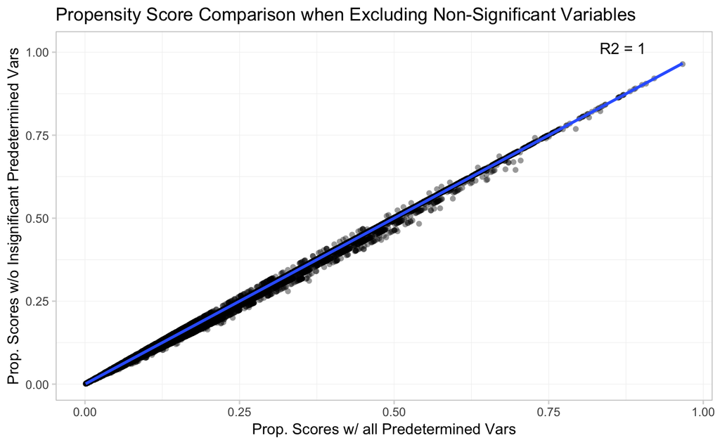

```r
ggscat(ps1,ps2, xlab = "Prop. Scores w/ all Predetermined Vars", ylab = "Prop. Scores w/o Insignificant Predetermined Vars", title = "Propensity Score Comparison when Excluding Non-Significant Variables")
```

Since these values of propensity scores are so similar, we can conclude more or less that we are including the “correct” set of predetermined variables in the smaller set of just those that enter significantly (p<0.05).

# 2b - Regression Adjusting Propensity Score Estimation

```r
dat.ps.reg <- dat.mod %>% select(c("dbrwt","tobacco")) %>% mutate(PropScore = ps2)
mod.2b <- lm(dbrwt ~., data = dat.ps.reg)
summary(mod.2b)
```

```
Call:
lm(formula = dbrwt ~ ., data = dat.ps.reg)

Residuals:
    Min      1Q  Median      3Q     Max
-3200.2  -309.1    29.8   361.9  2752.5

Coefficients:
            Estimate Std. Error t value Pr(>|t|)
(Intercept) 3435.035      2.775 1237.79   <2e-16 ***
tobacco     -221.924      4.943  -44.90   <2e-16 ***
PropScore   -165.491     14.537  -11.38   <2e-16 ***
---
Signif. codes:  0 ‘***’ 0.001 ‘**’ 0.01 ‘*’ 0.05 ‘.’ 0.1 ‘ ’ 1

Residual standard error: 578.2 on 114607 degrees of freedom
Multiple R-squared:  0.02373,   Adjusted R-squared:  0.02371
F-statistic:  1393 on 2 and 114607 DF,  p-value: < 2.2e-16
```

In this case of conditioning on the propensity scores and the treatment, the ATE of smoking while pregnant has risen to roughly -222 grams (i.e. smoking while pregnant will reduce infant birthweight by 222g, on average). However, for this approach to be sound, we assume conditions of unconfoundedness, overlap of treatment and controls in the covariate space, and a constant/homogenous treatement effect.

# 2c - Propensity Score Reweighting

Average treatment effect with reweighting propensity score:

```r
#Redefine final propensity score variable
pX <- ps2
# Define ATE with reweighted propensity score scheme
pATE <- sum(D*y/pX)/sum(D/pX) - sum((1-D)*y/(1-pX))/sum((1-D)/(1-pX))
pATE
```

```
[1] -222.9179
```

We can see that the ATE of -222.9179012 using this reweighted propensity score scheme returns a very similar value to the regression adjusted propensity score process above, suggesting that reweighting in this scenario may not make a large difference in the ATE estimate.

Average effect of the treatment on the treated

```r
TOT <- sum(D*y)/sum(D) - sum((pX*(1-D)*y)/(1-pX))/sum((pX*(1-D))/(1-pX))
TOT
```

```
[1] -220.9535
```

# 2d&e - kernel density estimator

For treatment

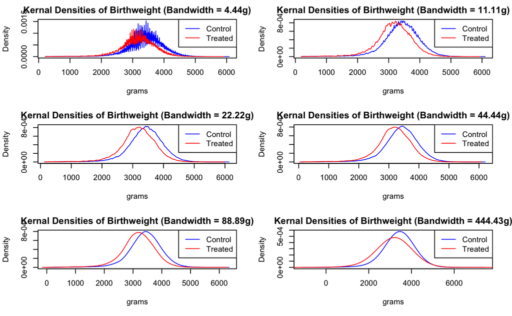

```r
#Number of Control Obs
nC <- length(D[D==0])
nT <- length(D[D==1])
par(mfrow = c(3,2))
for(adj in c(0.1,0.25,0.5,1,2,10)){
# Define Bandwidth
h0 <- density(y)$bw
bw_adjust <- adj
h <- h0*bw_adjust
# Control & Treatment Densities
Cdens <- density(y[D==0], adjust = bw_adjust)
Tdens <- density(y[D==1], adjust = bw_adjust)
#Plot densities
plot(Cdens, col = "blue", main = paste0("Kernal Densities of Birthweight (Bandwidth = ",round(h,2),"g)"), xlab = "grams")
lines(Tdens, col = "red")
legend('topright', legend = c("Control", "Treated"), col = c("blue", "red"), lty = 1)
}
```

The default bandwidth of ~44 grams seems to produce a fairly smooth kernal density, and was selected as the preferred bandwidth.

```r
h0 <- density(y)$bw
bw_adjust <- 1
h <- h0*bw_adjust
# Control & Treatment Densities
Cdens <- density(y[D==0], adjust = bw_adjust)
Tdens <- density(y[D==1], adjust = bw_adjust)
#Plot densities
plot(Cdens, col = "blue", main = paste0("Kernal Densities of Birthweight (Bandwidth = ",round(h,2),"g)"), xlab = "grams")
lines(Tdens, col = "red")
```

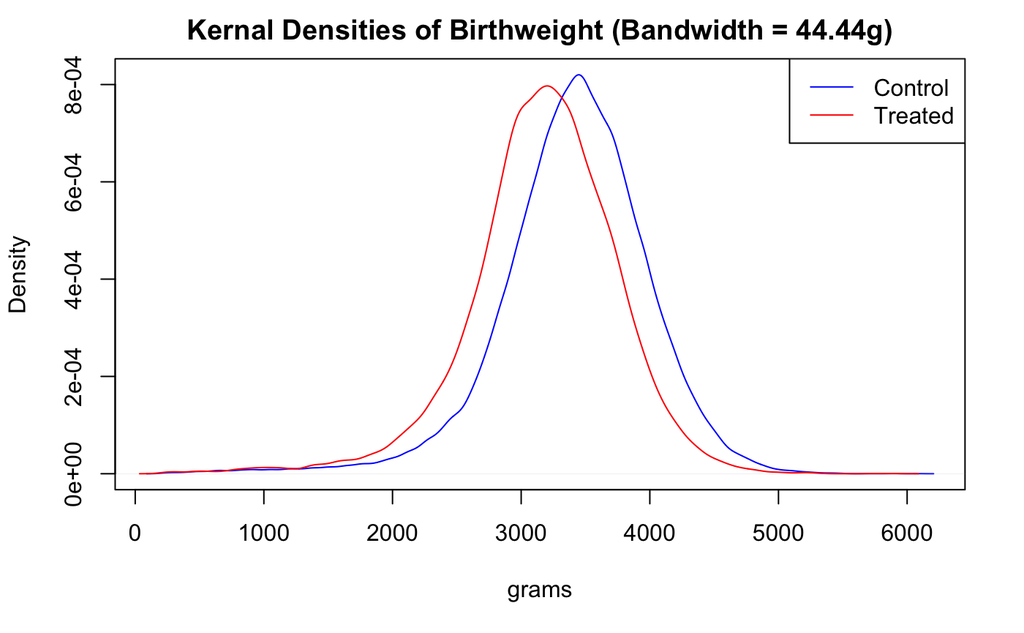

```r
legend('topright', legend = c("Control", "Treated"), col = c("blue", "red"), lty = 1)
```

Solving for kernel estimator at birthweight = 3000 grams.

```r
# Uniform kernal function
k.uni <- function(u){
  return(ifelse(abs(u) <= 1,0.5,0))
}
# Triangular kernal function
k.tri <- function(u){
  return(ifelse(abs(u) < 1,1-abs(u),0))
}
# Epanechnikov kernal function
k.epan <- function(u){
  return(ifelse(abs(u) < 1,0.75*(1-u^2),0))
}
# Gaussian kernal function
k.gauss <- function(u){
  return((1/sqrt(2*pi))*exp(-0.5*u^2))
}
# Kernal Density Estimator for Control Group
k.dens.C <- function(ystar, y, h, N, k.func){
  ks <- rep(NA,N)
  for(i in 1:N){
    u <- (ystar - y[i])/h
    ks[i] <- k.func(u)
  }
  return((1/(N*h))*(sum(ks)))
}
# Kernal Density Estimator for Treatment Group
k.dens.C <- function(ystar, k.func){
  ks <- rep(NA,nC)
  for(i in 1:nC){
    u <- (ystar - y[i])/h
    ks[i] <- k.func(u)*D[i]/pX[i]
  }
  return((1/(nC*h))*(sum(ks)))
}
# Kernal Density Estimator for Treatment Group
k.dens.T <- function(ystar, k.func){
  ks <- rep(NA,nT)
  for(i in 1:nT){
    u <- (ystar - y[i])/h
    ks[i] <- k.func(u)*(1-D[i])/(1-pX[i])
  }
  return((1/(nT*h))*(sum(ks)))
}
```

Kernal Estimates at 3000g

```r
h <- density(y)$bw
est.uni.C <- k.dens.C(3000,k.func = k.uni) %>% round(6)
est.tri.C <- k.dens.C(3000,k.func = k.tri) %>% round(6)
est.epan.C <- k.dens.C(3000,k.func = k.epan) %>% round(6)
est.gauss.C <- k.dens.C(3000,k.func = k.gauss) %>% round(6)
est.uni.T <- k.dens.T(3000,k.func = k.uni) %>% round(6)
est.tri.T <- k.dens.T(3000,k.func = k.tri) %>% round(6)
est.epan.T <- k.dens.T(3000,k.func = k.epan) %>% round(6)
est.gauss.T <- k.dens.T(3000,k.func = k.gauss) %>% round(6)
est.df <- data.frame(Kernal = c("Uniform","Triangular","Epanechnikov","Gaussian"), NonSmoker = c(est.uni.C,est.tri.C,est.epan.C,est.gauss.C),Smoker = c(est.uni.T,est.tri.T,est.epan.T,est.gauss.T))
kable(est.df, caption = "Kernal Estimates at Birthweight of 3000g")
```

[output not shown]

# 2e - bandwidth adjustments

In the above figure, we could see that with smaller bandwidths, the kernal densities get much more jagged, or variable. However, as we increase the bandwidth and the curves become smoother, it’s also evident that there is more bias in the estimates because the magnitudes of the curves begin to change relative to one another (i.e. the peak of the control curve starts to decline as the bandwidth is increased).

# 2f - benefits and drawbacks of propensity method

The benefits of the propensity weighting approach in part c is that it allows for conditioning solely on the likelihood of selecting into treatment, rather than on all predetermined control variables, which rectifies issues that arise when matching across many variables (Curse of Dimensionality). However, some drawbacks are that doing this process requires a number of assumptions to hold, such as unconfoundedness, overlap between treated and controls, and homogenous treatment effects.

# 2g - Present and discuss results

Assumptions 1 & 4 should hold I think (?)

# 3 - Blocking non-parametric approach

```r
bins <- seq(0,1,by = 0.01)
vals <- rep(NA, 100)
for(K in 1:100){
  bATE <- mean(y[pX >= bins[K] & pX < bins[K+1] & dat.mod$tobacco == 1]) - mean(y[pX >= bins[K] & pX < bins[K+1] & dat.mod$tobacco == 0])
  vals[K] <- bATE*length(y[pX >= bins[K] & pX < bins[K+1]])/length(y)
}
sum(vals[!is.nan(vals)])
```

```
[1] -220.2786
```

The ATE from this blocking approach is very similar to that found using propensity scores (very slightly smaller).

# 4 - low birth weights

```r
low.brwt <- dat.mod$dbrwt
low.brwt[low.brwt < 2500] <- 1
low.brwt[low.brwt >= 2500] <- 0
vals <- rep(NA, 100)
for(K in 1:100){
  bATE <- mean(low.brwt[pX >= bins[K] & pX < bins[K+1] & dat.mod$tobacco == 1]) - mean(low.brwt[pX >= bins[K] & pX < bins[K+1] & dat.mod$tobacco == 0])
  vals[K] <- bATE*length(low.brwt[pX >= bins[K] & pX < bins[K+1]])/length(low.brwt)
}
sum(vals[!is.nan(vals)])
```

```
[1] 0.03899595
```

This shows that smoking while pregnant increases the likelihood of having a low birthweight (<2500g) roughly 3.9 percent.

# 5 - Summarize results